# Linear Model

Yuanyuan Pan

October 15, 2016

## Week 3: Homework assignment: Simulation of 4 Linear Models

Set the values of slope (a) and intercept (b) parameters. Set the sample lengths to 1,000.

```r
# Slope and Intercept
a<-.8; b<-.1
nSample<-1000
```

### 1. Model 1

Simulate and plot Model1: input variable X ~ Norm($\mu=3,\sigma=2.5$); model residuals Eps ~ Norm($\mu=0,\sigma=1.5$) Use set.seed(111) to simulate $X$ and set.seed(1112131415) to simulate Eps.

```r
set.seed(111)
X <- rnorm(nSample, 3, 2.5)
set.seed(1112131415)
Eps <- rnorm(nSample, 0, 1.5)
Y <- a*X + b + Eps
LinearModel1 <- as.data.frame(cbind(Y, X, Eps))
```

Check the simulated model

```r
head(LinearModel1)
```

```
##            Y         X        Eps
## 1  1.3856455  3.588052 -1.5847959
## 2 -0.4957909  2.173160 -2.3343191
## 3  1.5640592  2.220940 -0.3126932
## 4 -1.8813610 -2.755864  0.2233303
## 5  5.4377138  2.572810  3.2794659
## 6  4.1192926  3.350696  1.3387362
```

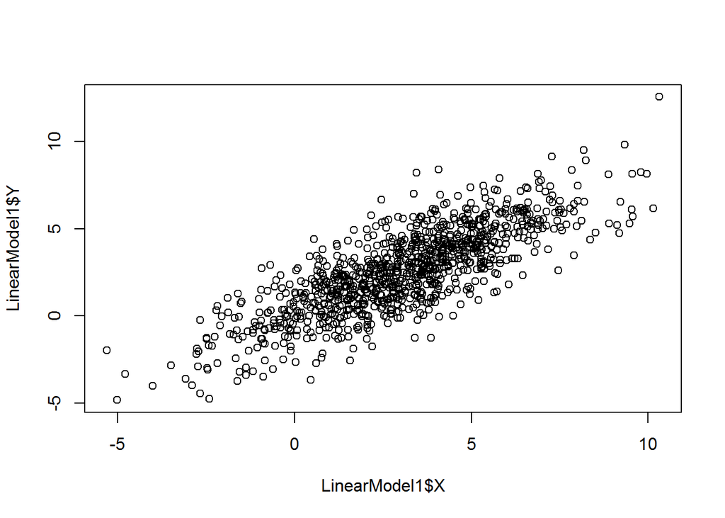

```r
plot(LinearModel1$X,LinearModel1$Y)
```

Plot the residuals of the model.

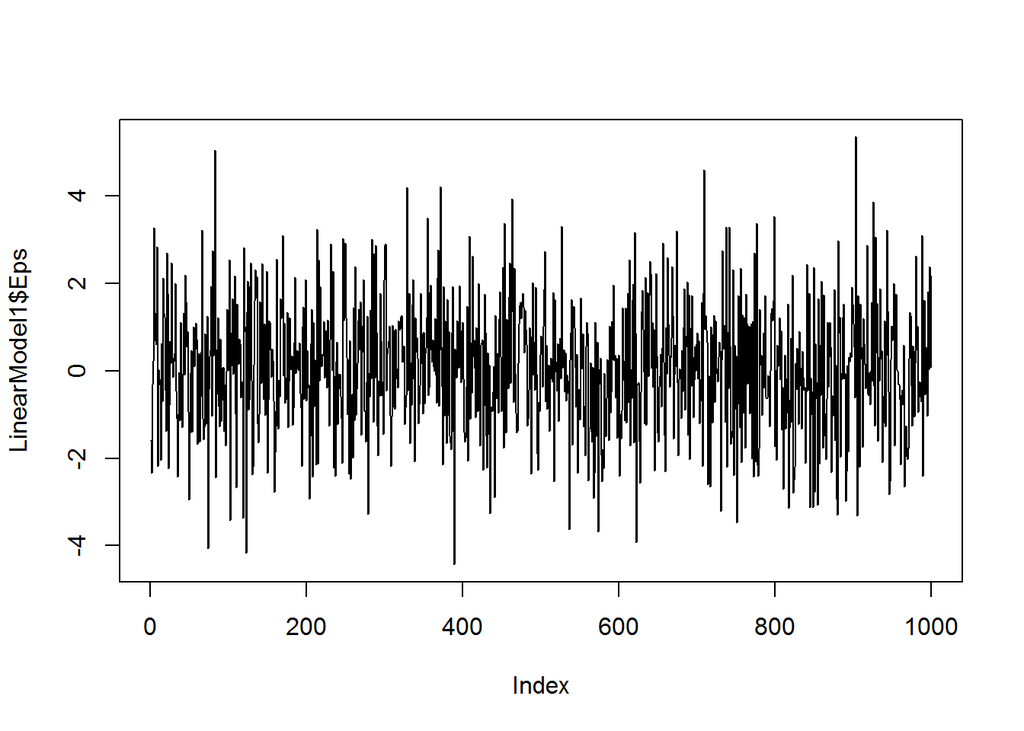

```r
plot(LinearModel1$Eps,type="l")
```

### 2. Model 2

Simulate and plot Model2: input variable X ~ Norm($\mu=3,\sigma=2.5$); model residuals Eps ~ Unif($min=-4.33,max=4.33$). Use the same realization of $X$ as in the first model. Use the same seed set.seed(1112131415) to simulate Eps. Plot the residuals of the model.

```r
set.seed(1112131415)
Eps <- runif(nSample, min = -4.33, max = 4.33)
Y <- a*X + b + Eps
LinearModel2 <- as.data.frame(cbind(Y, X, Eps))
head(LinearModel2)
```

```
##            Y         X         Eps
## 1 -0.1007155  3.588052 -3.07115695
## 2 -1.7495480  2.173160 -3.58807627
## 3 -1.9351307  2.220940 -3.81188300
## 4 -2.1321719 -2.755864 -0.02748057
## 5  1.4432271  2.572810 -0.71502082
## 6  0.6424869  3.350696 -2.13806956
```

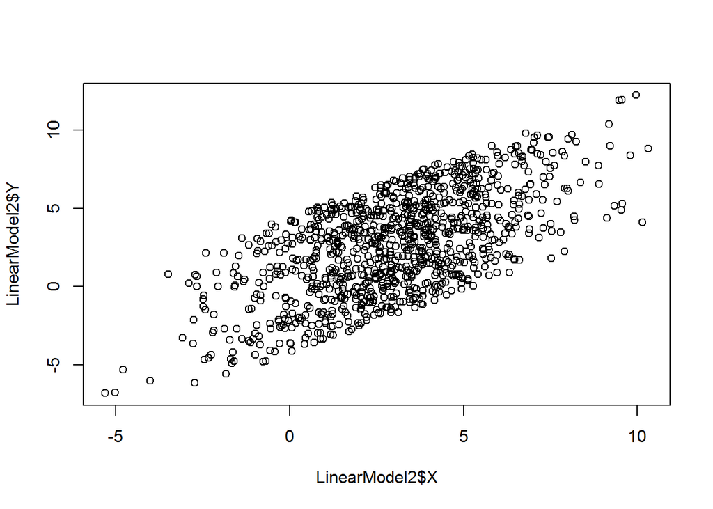

```r
plot(LinearModel2$X,LinearModel2$Y)
```

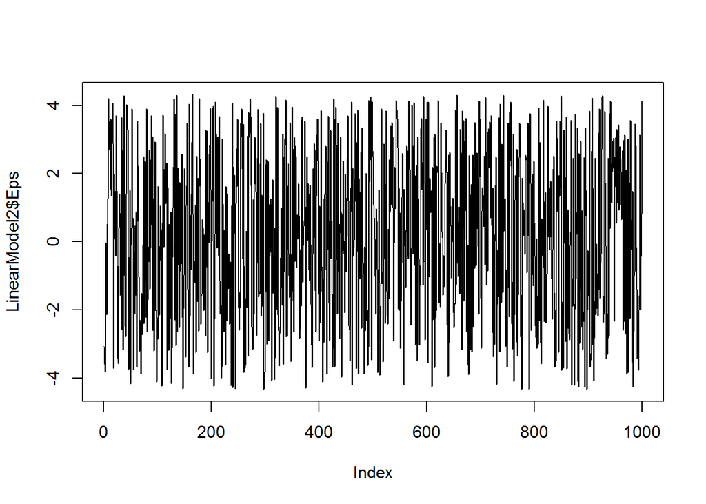

```r
plot(LinearModel2$Eps,type="l")
```

### 3. Model 3

Simulate and plot Model3: input variable X ~ Norm^($\mu=3,\sigma=2.5$); model residuals Eps ~ Cauchi*($location=0,scale=0.3$). Use the same realization of $X$ as in the first model. Use the same seed set.seed(1112131415) to simulate Eps. Plot the residuals of the model.

```r
set.seed(1112131415)
Eps <- rcauchy(nSample, location = 0, scale = 0.3)
Y <- a*X + b + Eps
LinearModel3 <- as.data.frame(cbind(X, Y, Eps))
head(LinearModel3)
```

```
##           X         Y         Eps
## 1  3.588052  3.117834  0.14739288
## 2  2.173160  1.921281  0.08275234
## 3  2.220940  1.933813  0.05706081
## 4 -2.755864 27.987178 30.09186936
## 5  2.572810  3.288758  1.13051049
## 6  3.350696  3.086476  0.30591976
```

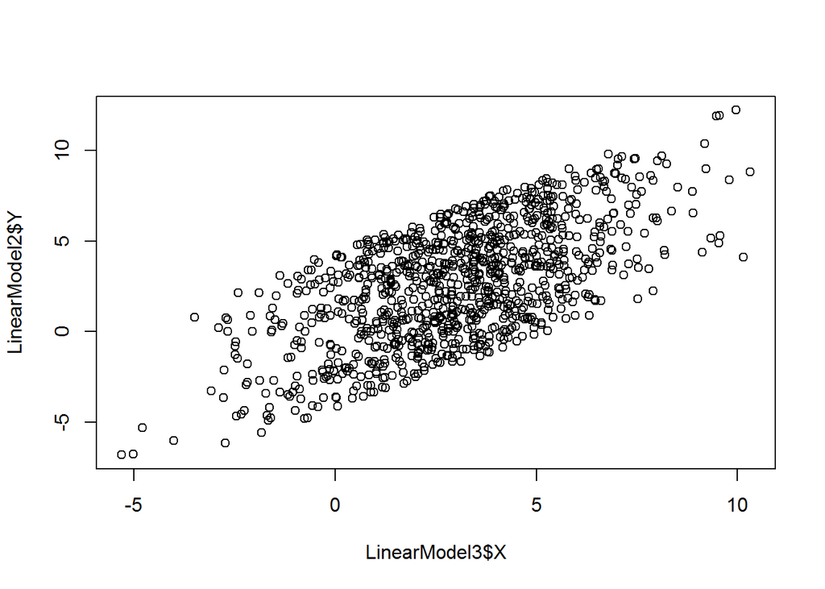

```r
plot(LinearModel3$X,LinearModel2$Y)
```

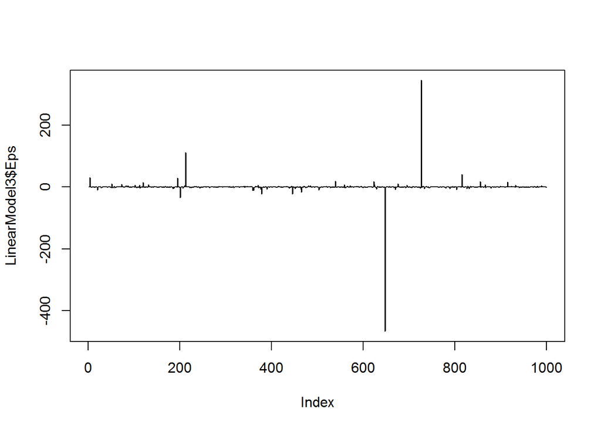

```r
plot(LinearModel3$Eps,type="l")
```

```r
sd(LinearModel3$Eps)
```

```
## [1] 18.98625
```

Generate another 5 samples of residuals without any seed specification and estimate standard deviations for each of them.

```r
Eps1<-rcauchy(n=nSample,location=0,scale=.3)
Eps2<-rcauchy(n=nSample,location=0,scale=.3)
Eps3<-rcauchy(n=nSample,location=0,scale=.3)
Eps4<-rcauchy(n=nSample,location=0,scale=.3)
Eps5<-rcauchy(n=nSample,location=0,scale=.3)
c(sd(Eps1),sd(Eps2),sd(Eps3),sd(Eps4),sd(Eps5))
```

```
## [1]   4.357834   7.316044 279.660160   4.778542   6.561620
```

The standard deviations varies a lot from sample to sample, sometimes became extremely large.

### 4. Model 4

Simulate and plot Model4: input variable X ~ Norm($\mu=3,\sigma=2.5$); model residuals Eps ~ a heteroscedastic process. Use the same realization of $X$ as in the first model. Use the same seed. Plot the residuals of the model.

Heteroscedasticity means that even though the model residuals Eps may be generated by a normal distribution, the standard deviation parameters for different sub samples are different.

Create the process of standard deviations in which the first 50 observations have sigma=2, followed by 75 observations with sigma=3.4, followed by 75 observations with sigma=0.8 and concluded by 50 observations with sigma=2.6.

Plot the trajectory of standard deviations of total length nSample=1000.

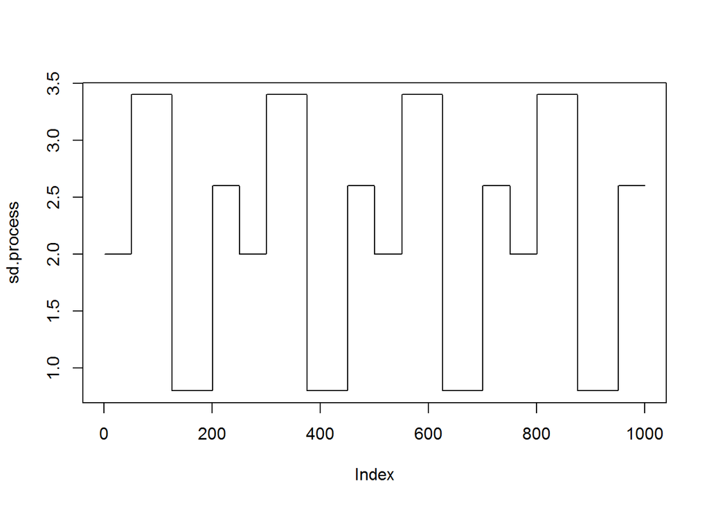

```r
sd.Values<-c(2,3.4,.8,2.6)
sd.process<-rep(c(rep(sd.Values[1],50),
                  rep(sd.Values[2],75),
                  rep(sd.Values[3],75),
                  rep(sd.Values[4],50)),
            4)

plot(sd.process,type="l")
```

Simulate the linear model residuals Eps with changing standard deviations.

```r
set.seed(1112131415);
Eps<-rnorm(nSample)*sd.process
```

Plot the residuals

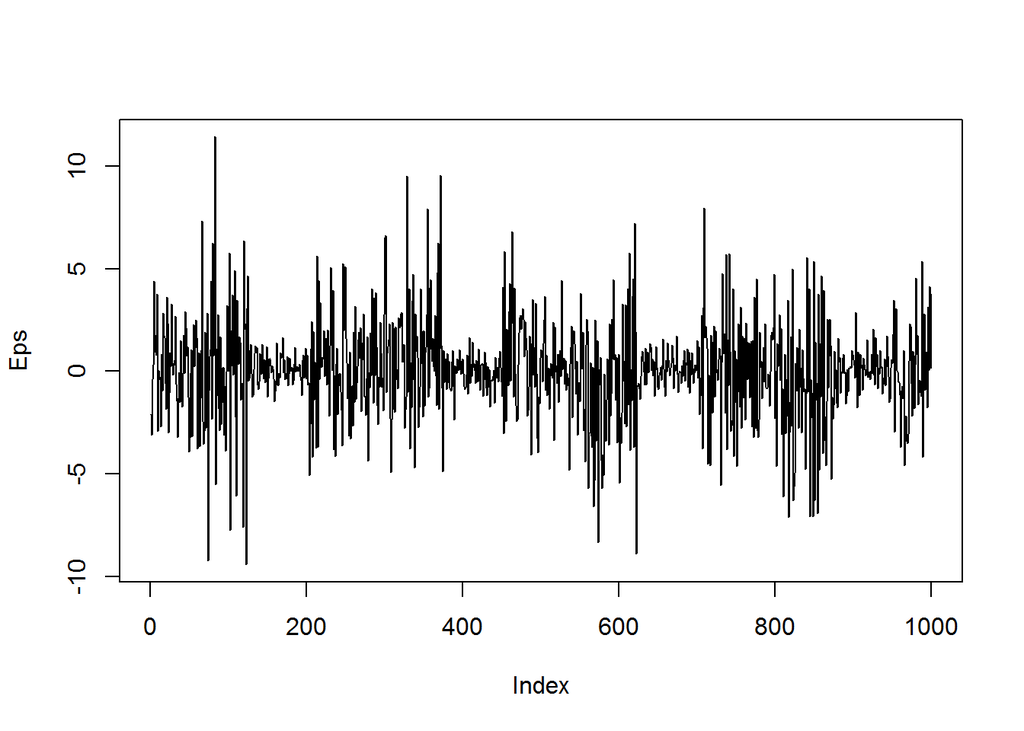

```r
plot(Eps,type="l")
```

Observe how heteroscedasticity transforms normal distribution into leptokurtic distribution

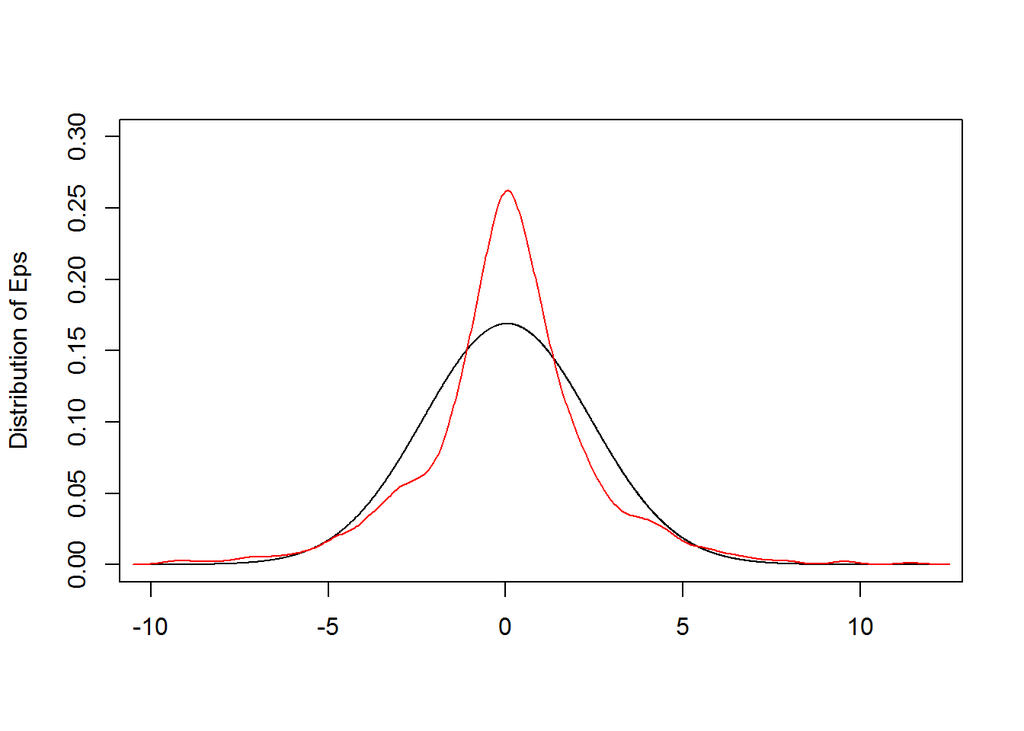

```r
Xvariable<-(100*floor(min(Eps))):(100*ceiling(max(Eps)))
Xvariable<-Xvariable/100
# Plot the sample distribution and the theo. distribution
plot(Xvariable,dnorm(Xvariable,mean=mean(Eps),sd=sd(Eps)),type="l",
      ylim=c(0,.3),col="black",ylab="Distribution of Eps",xlab="")
lines(density(Eps),col="red")
```

Generate LinearModel4. Plot it.

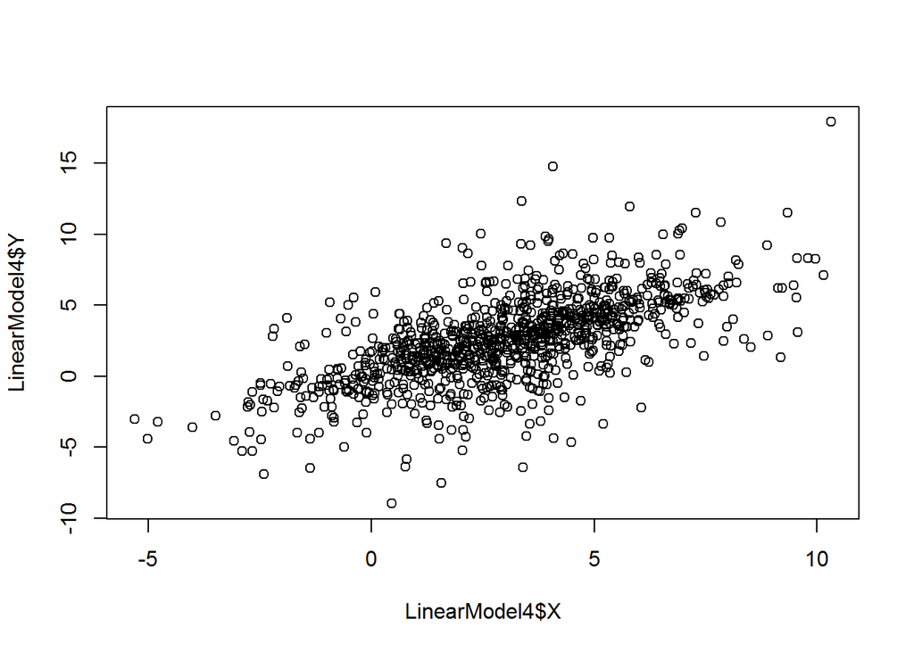

```r
Y<-a*X+b+Eps
LinearModel4<-as.data.frame(cbind(Y=Y,X=X))
plot(LinearModel4$X,LinearModel4$Y)
```

### 5. Effect of Residual Distribution on Correlation

Calculate the theoretical $\rho^{2}$ for the “correct model” which is LinearModel1.
$$Cov(X,Y) = a \sigma_x^2, \sigma_y^2 = a^2 \sigma_{x}^2 + \sigma_{\epsilon}^2.$$
$$\rho(X,Y) = \frac{Cov(X,Y)}{\sigma_x \sigma_y}$$
$$\rho(X,Y)^2 = \frac{(a \sigma_x)^2}{(a \sigma_x)^2+\sigma^2_{\epsilon}}$$

```r
# Theoretical Rho^2
Theoretical.Rho.Squared<-(a*sd(LinearModel1$X))^2/((a*sd(LinearModel1$X))^2+sd(LinearModel1$Eps)^2)
Theoretical.Rho.Squared
```

```
## [1] 0.6467077
```

And compare with the estimated $\rho^{2}$

```r
c(cor(LinearModel1$X,LinearModel1$Y)^2,
  cor(LinearModel2$X,LinearModel2$Y)^2,
  cor(LinearModel3$X,LinearModel3$Y)^2,
  cor(LinearModel4$X,LinearModel4$Y)^2)
```

```
## [1] 0.635937885 0.410346727 0.009230536 0.405022505
```

**How do you interpret the results?**

### 6. Estimation of Linear Model

Estimate parameters $a, b, \sigma$ using the function lm()

```r
m1<-lm(Y~X,data=LinearModel1)
summary(m1)
```

```
##
## Call:
## lm(formula = Y ~ X, data = LinearModel1)
##
## Residuals:
##     Min      1Q  Median      3Q     Max
## -4.4709 -0.9800  0.0003  0.9537  5.3112
##
## Coefficients:
##             Estimate Std. Error t value Pr(>|t|)
## (Intercept)  0.21129    0.07307   2.891  0.00392 **
## X            0.78109    0.01871  41.753  < 2e-16 ***
## ---
## Signif. codes:  0 '***' 0.001 '**' 0.01 '*' 0.05 '.' 0.1 ' ' 1
##
## Residual standard error: 1.46 on 998 degrees of freedom
## Multiple R-squared:  0.6359, Adjusted R-squared:  0.6356
## F-statistic:  1743 on 1 and 998 DF,  p-value: < 2.2e-16
```

```r
names(summary(m1))
```

```
##  [1] "call"          "terms"         "residuals"     "coefficients"
##  [5] "aliased"       "sigma"         "df"            "r.squared"
##  [9] "adj.r.squared" "fstatistic"    "cov.unscaled"
```

```r
summary(m1)$r.squared
```

```
## [1] 0.6359379
```

```r
summary(m1)$coeff
```

```
##              Estimate Std. Error   t value      Pr(>|t|)
## (Intercept) 0.2112857 0.07307137  2.891497  3.917289e-03
## X           0.7810888 0.01870749 41.752730 3.364178e-221
```

```r
summary(m1)$sigma^2
```

```
## [1] 2.132694
```

```r
var(summary(m1)$residuals)
```

```
## [1] 2.130559
```

Note the difference between summary(m1)$sigma^2 and var(summary(m1)$residuals). The estimate returned by the model is
$$\hat{\sigma}_{\epsilon,1}^2 = \frac{\sum_{i=1}^N residuals^2}{df} = \frac{\sum_{i=1}^N residuals^2}{N-2}.$$
But var() does not know anything about the model and its df. It estimates variance as
$$\hat{\sigma}_{\epsilon,2}^2 = \frac{\sum_{i=1}^N residuals^2}{N-1}.$$
The two estimates are reconciled by:
$$\hat{\sigma}_{\epsilon,1}^2 = \hat{\sigma}_{\epsilon,2}^2 \frac{N-1}{N-2}$$

```r
var(summary(m1)$residuals)*999/998
```

```
## [1] 2.132694
```

Estimate the same parameters using the method of moments directly.

```r
aEstimate <- cor(LinearModel1$X, LinearModel1$Y)*sd(LinearModel1$Y)/sd(LinearModel1$X)
bEstimate <- mean(LinearModel1$Y) - aEstimate*mean(LinearModel1$X)
sigmaEstimate <- sqrt(sd(LinearModel1$Y)^2-aEstimate^2*sd(LinearModel1$X)^2)
```

The result of estimation by method of moments is:

```r
c(aEstimate,bEstimate,sigmaEstimate)
```

```
## [1] 0.7810888 0.2112857 1.4596435
```

Reconcile sigmaEstimate with m1$sigma.

```r
c(sigmaMetodMoments=sigmaEstimate,sigmaLinearModel=summary(m1)$sigma)
```

```
## sigmaMetodMoments  sigmaLinearModel
##          1.459643          1.460375
```

### 7. Fit lm() to the the Rest of Linear Models

Compare the differences between the assumptions of the 4 models and tell how they change the model behavior and estimated parameters.

```r
m2 <- lm(LinearModel2$Y ~ LinearModel2$X)
m3 <- lm(LinearModel3$Y ~ LinearModel3$X)
m4 <- lm(LinearModel4$Y ~ LinearModel4$X)
summary(m2)$coeff
```

```
##                 Estimate Std. Error   t value      Pr(>|t|)
## (Intercept)    0.1626258 0.12307972  1.321305  1.867027e-01
## LinearModel2$X 0.8304188 0.03151046 26.353749 1.326871e-116
```

```r
summary(m2)$sigma
```

```
## [1] 2.459821
```

```r
summary(m2)$r.squared
```

```
## [1] 0.4103467
```

```r
summary(m2)$df
```

```
## [1]   2 998   2
```

```r
summary(m3)$coeff
```

```
##                 Estimate Std. Error   t value    Pr(>|t|)
## (Intercept)    0.3628702  0.9504455 0.3817896 0.702698690
## LinearModel3$X 0.7419727  0.2433299 3.0492458 0.002354668
```

```r
summary(m3)$sigma
```

```
## [1] 18.99522
```

```r
summary(m3)$r.squared
```

```
## [1] 0.009230536
```

```r
summary(m3)$df
```

```
## [1]   2 998   2
```

```r
summary(m4)$coeff
```

```
##                 Estimate Std. Error   t value      Pr(>|t|)
## (Intercept)    0.1724487 0.11817209  1.459302  1.447967e-01
## LinearModel4$X 0.7885655 0.03025403 26.064811 1.184840e-114
```

```r
summary(m4)$sigma
```

```
## [1] 2.361739
```

```r
summary(m4)$r.squared
```

```
## [1] 0.4050225
```

```r
summary(m4)$df
```

```
## [1]   2 998   2
```

### Test 3

```r
df <- read.table('Week3_Test_Sample.csv', header = TRUE)
Model <- lm(df$Y ~ df$X)
summary(Model)$coeff
```

```
##              Estimate Std. Error   t value      Pr(>|t|)
## (Intercept) -3.086629 0.16215399 -19.03517  3.670753e-69
## df$X         1.453373 0.04151413  35.00912 8.172467e-176
```

```r
mean(Model$residuals)
```

```
## [1] 1.090595e-16
```

```r
sd(Model$residuals)
```

```
## [1] 3.239121
```

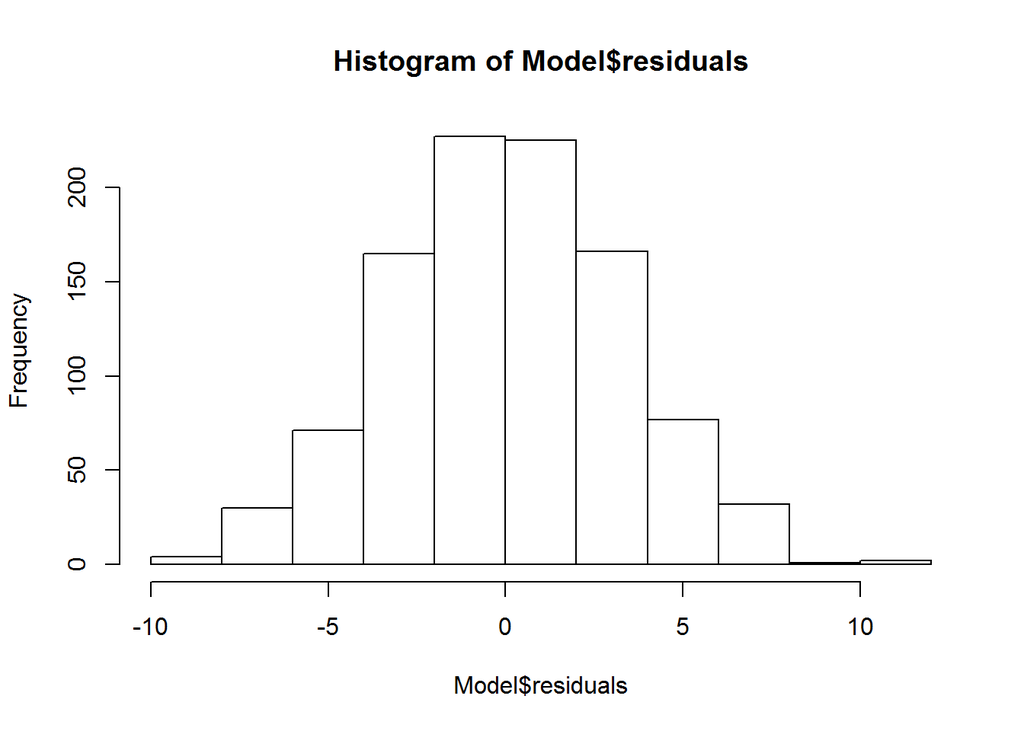

```r
hist(Model$residuals)
```

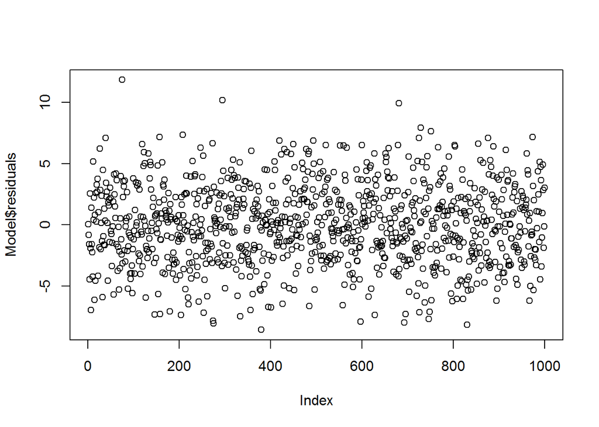

```r
plot(Model$residuals)
```